# Prediction Model

Shira Wild, Maayan Aviram and Noa Radin

Load the datasets:

```r
covid_concern <- read_rds(here::here("data", "covid_concern.rds"))
trump_tweets_origin <- read_rds(here::here("data", "trump_tweets.rds"))
combined_tweets_concern<-read_rds(here::here("data", "combined_tweets_concern.rds"))
only_covid<-read_rds(here::here("data", "only_covid.rds"))
```

Finding the most common words and phrases:

```r
# using "unnest_tokens" to find the different words and phrases that that recurring
trump_tweets_words<-trump_tweets_origin%>%
  unnest_tokens(bigram, Text, token = "ngrams", n = 2, n_min =1)

colnames(trump_tweets_words)[7]<-"word"

#counting the words and phrases
trump_tweets_words%>%
  count(word,sort=TRUE)%>% head(10)
```

```
##          word    n
## 1         the 1539
## 2          to  924
## 3          rt  866
## 4         and  721
## 5          of  646
## 6           a  580
## 7       https  516
## 8  https t.co  500
## 9        t.co  500
## 10         is  431
```

A lot of words are ‘stop words’, so we will remove them by using ‘anti_join’ with the `stop_words` dataset.

```r
trump_tweets_words <- trump_tweets_words %>%
  anti_join(stop_words, by = "word")
```

In order to get the best prediction, we will filter the tweets to tweets that related to corona, by using key words.

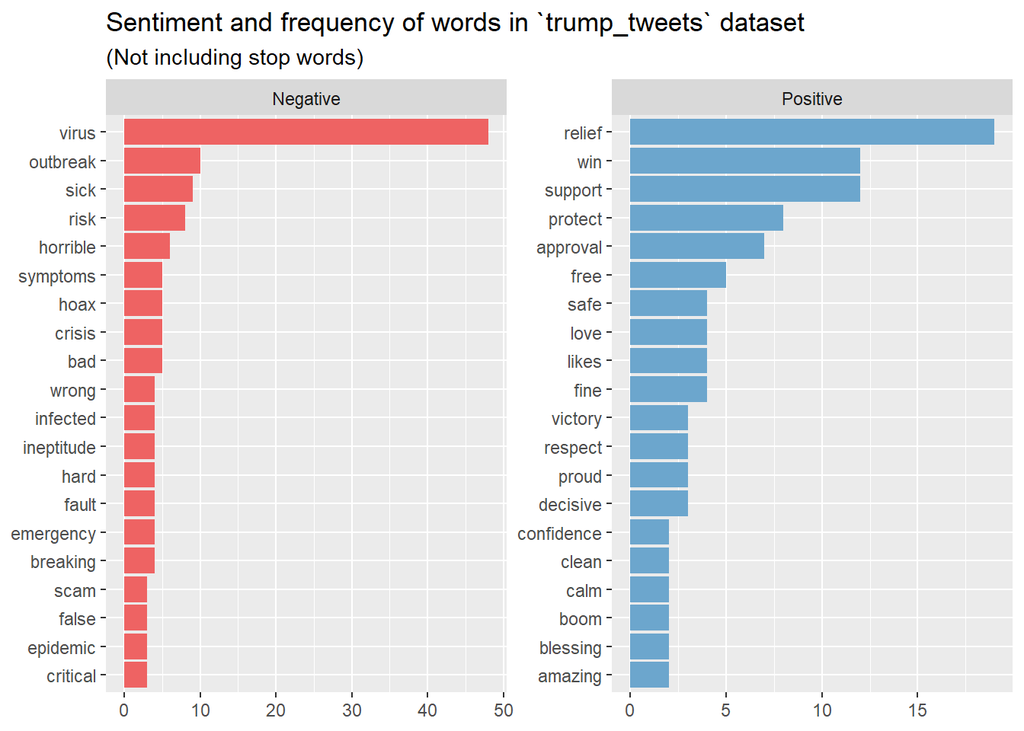

```r
# filter tweets by covid related tweets
covid_related <- c("coronavirus","covid19","covid","covid19pandemic","corona","pandemic","epidemic","virus")

only_covid <- trump_tweets_words%>%
  filter(word %in% covid_related)
write_rds(only_covid,file = here::here("data", "only_covid.rds"))

covid_tweets_ids <- unique(only_covid$Id)

covid_tweets <- trump_tweets_words%>%
    filter(Id %in% covid_tweets_ids)

# words that are not inconclusive - not negtive or positive.
not_in<-c("trump","positive","strong","significant","fast","fake","slow")

# also joining the `covid_tweets` with sentiments of 'bing' - classifies each word to negative or positive
sentiment_words <- get_sentiments("bing")
sentiment_words$sentiment[sentiment_words$sentiment == "positive"] <- "Positive"
sentiment_words$sentiment[sentiment_words$sentiment =="negative"] <- "Negative"

only_top_words<-covid_tweets %>%
  filter(!(word %in% not_in)) %>%
  inner_join(sentiment_words, by = "word") %>%
  count(sentiment, word, sort = TRUE) %>%
  group_by(sentiment)

only_top_words <-only_top_words %>% slice_head(n = 20)

# we would like to see the most negative and positive words in trump's tweets
ggplot(data=only_top_words,aes(y = fct_reorder(word, n), x = n, fill = sentiment)) +
geom_col(show.legend = FALSE) +
facet_wrap(~sentiment, scales = "free") +
labs(title = "Sentiment and frequency of words in `trump_tweets` dataset",
     subtitle = "(Not including stop words)", y = NULL, x = NULL) +
scale_fill_manual(values = c("indianred2", "skyblue3"))
```

In order to analyze the sentiment of the tweets, we will join the original tweets with the words data. We will count the amount of ‘Positive’ and ‘Negative’ words in each day, and classify each day to be Positive or Negative.

```r
top_with_trump <- only_top_words %>%
  inner_join(trump_tweets_words, by = "word")

# get the amount of each word in certain date
grouped_words <- top_with_trump %>%
  group_by(Date,sentiment) %>%
  summarise(count_words = n(),.groups='drop')

# each day will include `Positive` and `Negative` columns with the amount of the suitable sentiment words
pivoted_tweets <- pivot_wider(grouped_words, id_cols = NULL, names_from = sentiment, values_from = count_words)
pivoted_tweets[is.na(pivoted_tweets)] <- 0
pivoted_tweets$SentScore<- pivoted_tweets$Positive-pivoted_tweets$Negative
pivoted_tweets$Type<-"Negative"
pivoted_tweets$Type[pivoted_tweets$SentScore>0] <- "Positive"
pivoted_tweets$Type[pivoted_tweets$SentScore==0] <- "Neutral"
head(pivoted_tweets)
```

```
## # A tibble: 6 x 5
##   Date       Positive Negative SentScore Type
##   <date>        <int>    <int>     <int> <chr>
## 1 2020-02-24        1        0         1 Positive
## 2 2020-02-25        1        2        -1 Negative
## 3 2020-02-26        7        6         1 Positive
## 4 2020-02-28        3       10        -7 Negative
## 5 2020-02-29        2        0         2 Positive
## 6 2020-03-01        3        6        -3 Negative
```

The `sentScore` column, is a subscription of `Positive` by `Negative` and it indicates the sentiment score of a day. If the `sentScore` is bigger than 0, that day is Positive, If it is lower than 0, that day is Negative. There are also some `Neutral` days.

```r
# join the relevant tweets with `covid_concern`
combined_tweets_concern<-covid_concern %>%
  left_join(pivoted_tweets, by = "Date")
combined_tweets_concern[is.na(combined_tweets_concern)] <- 0
combined_tweets_concern$Type[combined_tweets_concern$Type=="0"] <- "Neutral"
write_rds(combined_tweets_concern,file = here::here("data", "combined_tweets_concern.rds"))

head(combined_tweets_concern)
```

```
##         Date Democrats Republicans Difference Positive Negative SentScore
## 1 2020-02-25        35         -57         92        1        2        -1
## 2 2020-02-26        35         -58         93        7        6         1
## 3 2020-02-27        35         -58         93        0        0         0
## 4 2020-02-28        35         -58         93        3       10        -7
## 5 2020-02-29        36         -58         94        2        0         2
## 6 2020-03-01        37         -58         95        3        6        -3
##       Type
## 1 Negative
## 2 Positive
## 3  Neutral
## 4 Negative
## 5 Positive
## 6 Negative
```

Let’s do some exploration:

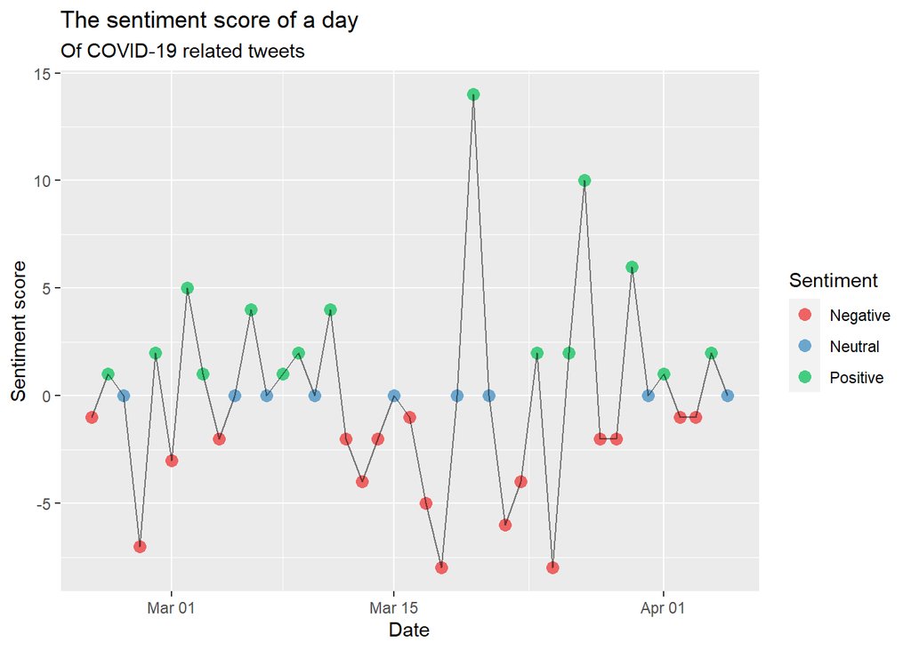

```r
ggplot(data=combined_tweets_concern, aes(x=Date,y=SentScore, color = Type))+
  geom_point(size = 3)+
  scale_color_manual(values = c( "indianred2","skyblue3", "seagreen3"))+
  geom_line(alpha = 0.5, color = "black")+
  labs(title = "The sentiment score of a day",subtitle = "Of COVID-19 related tweets", y = "Sentiment score", color = "Sentiment")
```

We can see that the distribution of the negative and positive days is pretty random, and that the middle of March is mostly negative.

#### First variable - Negativity Level

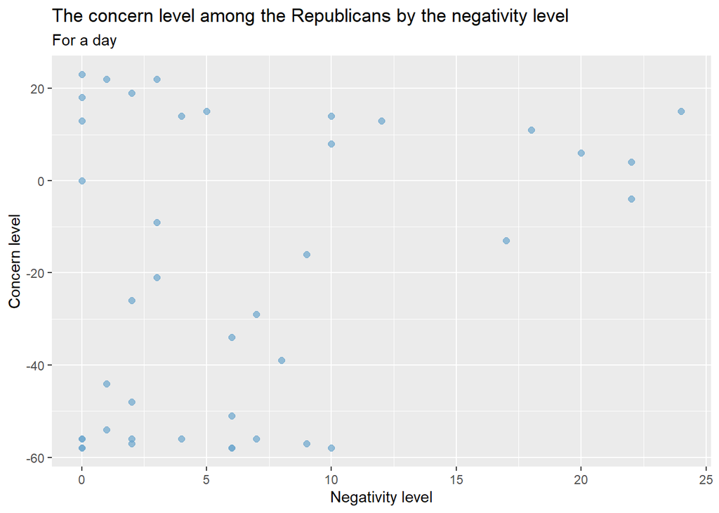

```r
ggplot(data = combined_tweets_concern, aes(x = Negative, y = Republicans))+
  geom_point(alpha = 0.7, size = 2, color = 'skyblue3')+
  labs(title = "The concern level among the Republicans by the negativity level", subtitle = "For a day", x = "Negativity level", y = "Concern level")
```

We can not find a clear connection between the variables, but we can see that for negativity amount that’s bigger than 10 - the average concern level is higher.

#### Second variable - Number of tweets

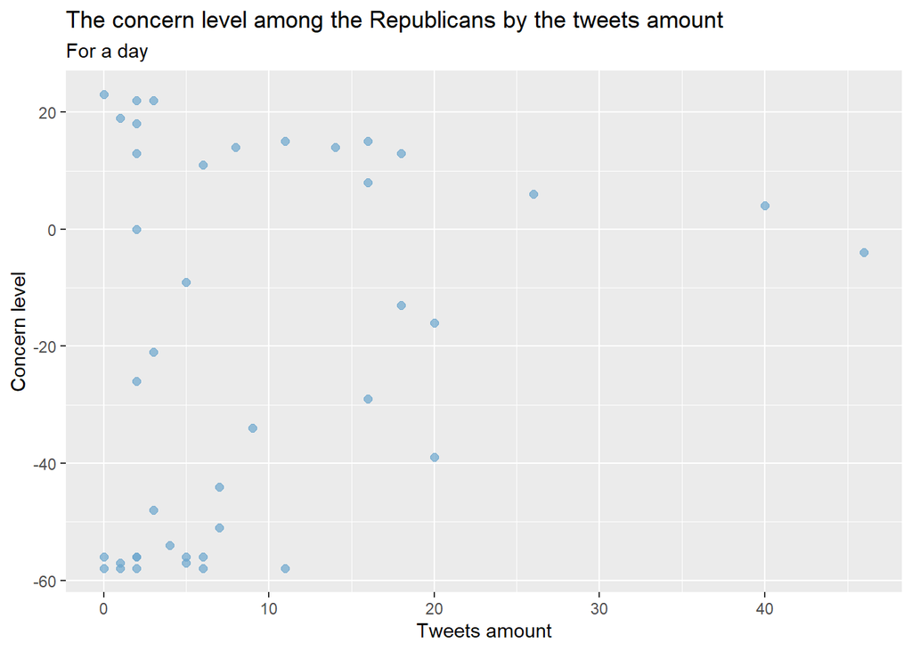

```r
# count the amount of tweets in each day
by_number_of_tweets <- only_covid %>%
  group_by(Date)%>%
  summarise(Number_of_tweets = n()) %>%
  right_join(covid_concern, by = "Date")

# days without tweets - fill with 0
by_number_of_tweets[is.na(by_number_of_tweets)]<-0

ggplot(data = by_number_of_tweets, aes(x = Number_of_tweets, y = Republicans))+
  geom_point(alpha = 0.7, size = 2, color = 'skyblue3')+
  labs(title = "The concern level among the Republicans by the tweets amount", subtitle = "For a day", x = "Tweets amount", y = "Concern level")
```

Again, we can not find a clear connection between the variables, but we can see that for very high amount of tweets in a day (more than 20) the average concern level is higher.

#### Third variable - Sum of Retweets

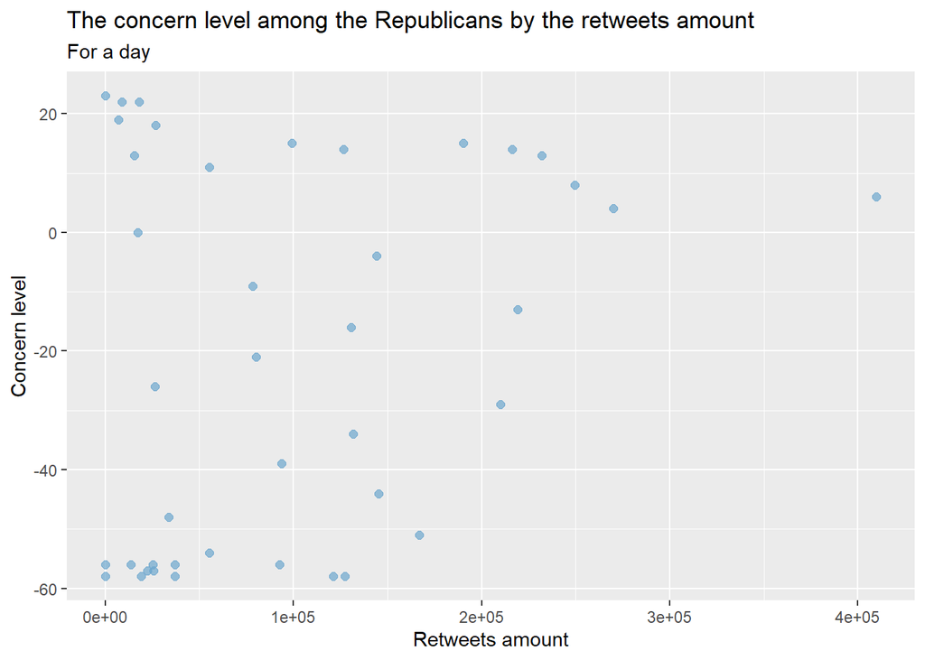

```r
covid_ids <- unique(only_covid$Id)

#count the amount of retweets in a day and join with `covid_retweet`
by_retweet <- trump_tweets_origin%>%
  filter(Id %in% covid_ids)%>%
  group_by(Date)%>%
  summarise(Sum_rt_per_date = sum(Retweets))%>%
  right_join(covid_concern, by = "Date")

#fill empty with 0
by_retweet[is.na(by_retweet)]<-0

ggplot(data = by_retweet, aes(x = Sum_rt_per_date, y = Republicans))+
  geom_point(alpha = 0.7, size = 2, color = 'skyblue3')+
  labs(title = "The concern level among the Republicans by the retweets amount", subtitle = "For a day", x = "Retweets amount", y = "Concern level")
```

Again, we can not find a clear connection between the variables, but we can see that for very high amount of retweets in a day the average concern level is higher.

We checked 3 variables that might have help us predict the concern level among Americans. Since none of them clearly showed a connection, we will try to combine between the different variables and predict the concern level by few variables. For the prediction model we would like to check the connection between the Republicans’ concern level to some variables. When we preformed the exploration we discovered that the trend line of the republicans and the democrats is very similar, so we will only show the exploration of the republicans.

Making some preparation to save the combined dataset:

```r
#combine datasets with all the variables - `Sum_rt_per_date`, `Number_of_tweets`, `Negative`
combined_dataset <- by_retweet%>%
  inner_join(by_number_of_tweets, by = c("Date","Republicans","Democrats","Difference"))%>%
  inner_join(combined_tweets_concern, by = c("Date","Republicans","Democrats","Difference"))

head(combined_dataset)
```

```
## # A tibble: 6 x 10
##   Date       Sum_rt_per_date Democrats Republicans Difference Number_of_tweets
##   <date>               <dbl>     <int>       <int>      <int>            <int>
## 1 2020-02-25           25611        35         -57         92                1
## 2 2020-02-26          121238        35         -58         93               11
## 3 2020-02-28          127348        35         -58         93                6
## 4 2020-02-29           19178        36         -58         94                1
## 5 2020-03-01           36929        37         -58         95                2
## 6 2020-03-02           22633        37         -57         94                5
## # ... with 4 more variables: Positive <dbl>, Negative <dbl>, SentScore <dbl>,
## #   Type <chr>
```

This is the table that includes all of the variables we would like to make prediction with.

Saving the table to rds:

```r
write_rds(combined_dataset, file = here::here("data", "tweets_concern.rds"))
```

### Is it possible to predict the level of concern among the american public (Democrats and Republicans) by Donald Trump’s tweets, According to the level of negativity in the tweets, the number of tweets and the number of his tweets’ retweets by day.

Our goal is to find a straight connection between each variable to the concern level. We expect to see that for the `Negativity level` the concern level will rise as the Negativity level rises especially for the Republicans because they support and believe in Trump’s opinions. For the `number of tweets` we also expect to find as the amount of tweets in a day rises the concern level also rises. That is because a lot of tweets might indicate emergency and stress. We also expect to see that as the `number of retweets` on Trump’s tweets rises in a day the concern level also rises, maybe because it’s indicates that the American people (Republicans especially) are involved and concerned about the situation.

```r
tweets_concern <- read_rds(here::here("data", "tweets_concern.rds"))
```

#### Build Simple model Simulation

In order to pick the best combination of these three variables, we will build a simple linear regression model and test the different combinations. In the exploration we observed that the relationship between the Democrats and the different variables and the relationship between the Republicans and the different variables is very similar so we decided to build the model based only on the republicans and after we will finish the building process, we will predict on both variables.

```r
simple_model <- function(dataset,engine){
  # set a seed for the model
  set.seed(111)
  # train / test
  train_test_data <- initial_split(rep_tweets_concern)
  covid_train <- training(train_test_data)
  covid_test <- testing(train_test_data)
  # specify model
  covid_mod <- linear_reg(penalty = 0.005, mixture = 1) %>%
    set_engine(engine)
  # build recipe
  covid_rec <- recipe(Republicans ~ ., data = covid_train )
  # build workflow
  covid_wflow <- workflow() %>%
    add_model(covid_mod) %>%
    add_recipe(covid_rec)
  # fit model
  covid_fit <- covid_wflow %>%
    fit(data=covid_train)
  # evaluate model
  covid_train_pred <- predict(covid_fit, covid_train) %>%
    bind_cols(covid_train %>% select(Republicans))
  rmse<-rmse(covid_train_pred, truth = Republicans, estimate = .pred)
  rsq<-rsq(covid_train_pred, truth = Republicans, estimate = .pred)
  return(c(rmse$.estimate[1],rsq$.estimate[1]))
}
```

Now, let’s perform this process for each combination

```
##                                  RMSE        RSQ
## Sum_retweets                 29.37689 0.06801123
## Num_of_tweets                29.10501 0.08518230
## Negative_score               29.31649 0.07184013
## Sum_retweets_Number_tweets   29.01248 0.09099427
## Negative_score_Sum_retweets  29.18392 0.08021880
## Negative_score_Number_tweets 29.07632 0.08698931
## All_Variables                29.00945 0.09118431
```

We found the best model, we will use `Number_of_tweets`, `Negative score` and `Sum of retweets` variables. We saw in the simple model that this combination creates a model with the highest RSQ score.

#### Building the linear regression model

First we will select the variables for the model

```r
rep_tweets_concern <- tweets_concern %>%
  select(Republicans,Negative,Sum_rt_per_date,Number_of_tweets)
```

Now, let’s build the basic model

```r
# Split the data into train and test
set.seed(111)
train_test_data <- initial_split(rep_tweets_concern)
covid_train <- training(train_test_data)
covid_test  <- testing(train_test_data)

# Specify the model
covid_mod <- linear_reg(penalty = 0.005, mixture = 1) %>%
  set_engine("glmnet")

# Build recipe
covid_rec <- recipe(Republicans ~ ., data = covid_train)

# Build workflow
covid_wflow <- workflow() %>%
  add_model(covid_mod) %>%
  add_recipe(covid_rec)
```

Next, we will use the k-folds cross validation

```r
set.seed(111)

# Set folds
covid_folds <- vfold_cv(covid_train, v = 11)

# Fit the model
covid_fit_rs <- covid_wflow %>%
  fit_resamples(covid_folds,control = control_resamples(save_pred = TRUE))

# Collect the fit results
covid_train_metrics <- collect_metrics(covid_fit_rs)
covid_train_pred <- collect_predictions(covid_fit_rs)
```

Let’s take a look at the metrics of this model

```r
covid_train_metrics %>% clean_names()
```

```
## # A tibble: 2 x 6
##   metric estimator   mean     n std_err config
##   <chr>  <chr>      <dbl> <int>   <dbl> <chr>
## 1 rmse   standard  31.7      11   2.91  Preprocessor1_Model1
## 2 rsq    standard   0.543    11   0.131 Preprocessor1_Model1
```

And use the tuning and try to improve the model

```r
# Specify the tuned model
covid_mod_tune <- linear_reg(penalty = tune(), mixture = tune()) %>%
  set_engine("glmnet")

# Build the new workflow
covid_wflow_tune <- workflow() %>%
  add_model(covid_mod_tune) %>%
  add_recipe(covid_rec)

# Define the grid
penalty_mixture_grid <- grid_regular(penalty(range = c(-2, 0)),mixture(range=c(0,1)), levels = 5)

# Fit the tuned model
covid_fit_rs_tune <- tune_grid(
 covid_wflow_tune,
 resamples = covid_folds,
 grid = penalty_mixture_grid,
 control = control_grid(save_pred = TRUE)
)

# Collect the fit results
collect_metrics(covid_fit_rs_tune) %>%
  clean_names() %>%
  filter(metric=="rsq") %>%
  arrange(desc(mean)) %>%
  head(5)
```

```
## # A tibble: 5 x 8
##   penalty mixture metric estimator  mean     n std_err config
##     <dbl>   <dbl> <chr>  <chr>     <dbl> <int>   <dbl> <chr>
## 1    1       1    rsq    standard  0.628    11   0.125 Preprocessor1_Model25
## 2    1       0.75 rsq    standard  0.583    11   0.121 Preprocessor1_Model20
## 3    1       0.5  rsq    standard  0.546    11   0.130 Preprocessor1_Model15
## 4    0.1     1    rsq    standard  0.543    11   0.131 Preprocessor1_Model23
## 5    0.01    1    rsq    standard  0.543    11   0.131 Preprocessor1_Model21
```

We can see that the `RSQ` is the highest with penalty and mixture values. So let’s build the final model using this parameters.

#### Building the final model

```r
prediction_model <- function(dataset,col_name){

  # Select variables for the model
  if (col_name=="Democrats"){
    rep_tweets_concern <- dataset %>%
      select(Democrats,Negative,Sum_rt_per_date,Number_of_tweets)
  }
  else{
    rep_tweets_concern <- dataset %>%
      select(Republicans,Negative,Sum_rt_per_date,Number_of_tweets)
  }

  # Split to train and test
  set.seed(111)
  splits <- initial_split(rep_tweets_concern)
  covid_train <- training(splits)

  # Build recipe
  if (col_name=="Democrats"){
    covid_rec <- recipe(Democrats ~ ., data = covid_train)
  }
  else{
    covid_rec <- recipe(Republicans ~ ., data = covid_train)
  }

  # Build the new workflow
  covid_wflow_tune <- workflow() %>%
    add_model(covid_mod_tune) %>%
    add_recipe(covid_rec)

  best<-select_best(covid_fit_rs_tune, "rsq")

  covid_wflow_final_ds<-finalize_workflow(covid_wflow_tune, best)

  # Last fit for the model
  covid_fit_final_ds <- last_fit(
    covid_wflow_final_ds,
    splits)

  # Save the model result in a file.
  filename = paste(col_name,".rds",sep="")
  write_rds(covid_fit_final_ds, here::here("model-output", filename), compress = "bz2")
}
```

Now, we will make the prediction for each group

```r
prediction_model(tweets_concern,"Democrats")
prediction_model(tweets_concern,"Republicans")
```

#### Building process summary

In the exploration we observed that there are no strong connections between different variables and the concern level. We will not expect the model to predict the concern level optimally.

As can be seen in the prediction process, at the beginning of the prediction we used simple models of linear regression, and the prediction results were not optimal. After using the simple model, we decided to improve the model by using k-fold cross-validation, the prediction improved. The next improvement was the use of tuning to change the penalty value and the mixture value of the model. Next, we build the final model and forecast in advance on the Democrats’ concern rate and the Republicans’ concern rate.

#### Visualization

Let’s extract the results of the model’s prediction on the Democrats’ concern rate.

```r
demo<-read_rds(here::here("model-output", "Democrats.rds"))
tweets_concern$Row <- seq.int(nrow(tweets_concern))

# Extract the metrics of the model
rmse_rsq_D<-demo %>%
  collect_metrics()%>% clean_names()

# Extract the predictions of the model
pred_D<-demo %>%
  collect_predictions() %>% clean_names()
colnames(pred_D)<-c("Id","Pred","Row","Democrats","Config")

# Join with the tweets_concern dataset
Democrats_pred<-tweets_concern %>%
  inner_join(pred_D,by=c("Row","Democrats"))

for_pearson<-Democrats_pred%>%
  select("Democrats","Pred")

corr_d<-cor(for_pearson, method = "pearson")[1,2]
d<-rbind(rmse_rsq_D[c(1,3)],c("pearson",corr_d))
colnames(d)<-c("Metric","Estimate")
d
```

```
## # A tibble: 3 x 2
##   Metric  Estimate
##   <chr>   <chr>
## 1 rmse    16.5515711092782
## 2 rsq     0.396112560412551
## 3 pearson 0.629374737666321
```

Now we will extract the results of the model’s prediction on the Republicans’ concern rate.

```r
rep<-read_rds(here::here("model-output", "Republicans.rds"))

# Extract the metrics of the model
rmse_rsq_R<-rep %>%
  collect_metrics()%>% clean_names()

# Extract the predictions of the model
pred_R<-rep %>%
  collect_predictions() %>% clean_names()
colnames(pred_R)<-c("Id","Pred","Row","Republicans","Config")

# Join with the tweets_concern dataset
Republicans_pred<-tweets_concern %>% inner_join(pred_R,by=c("Row","Republicans"))

for_pearson<-Republicans_pred%>%
  select("Republicans","Pred")

corr_r<-cor(for_pearson, method = "pearson")[1,2]
r<-rbind(rmse_rsq_R[c(1,3)],c("pearson",corr_r))
colnames(r)<-c("Metric","Estimate")
r
```

```
## # A tibble: 3 x 2
##   Metric  Estimate
##   <chr>   <chr>
## 1 rmse    28.8912144517324
## 2 rsq     0.322816677650337
## 3 pearson 0.568169585291519
```

Lets see the model’s results in the following graphs.

#### Democrats prediction

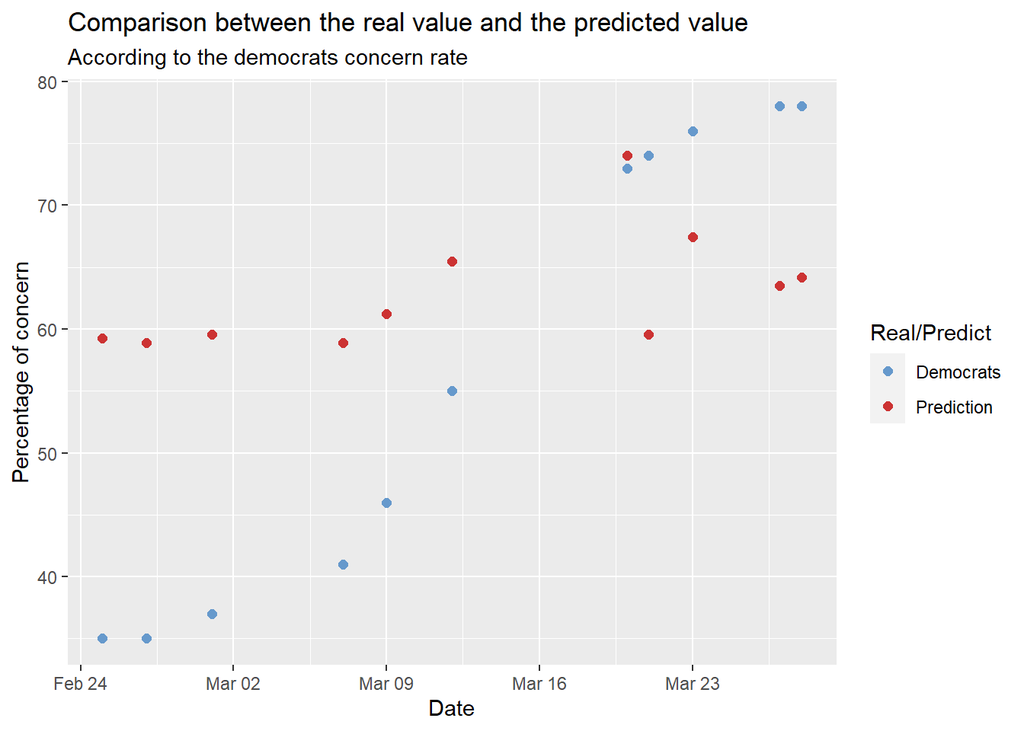

```r
colors <- c("Democrats" = "#6699cc", "Prediction" = "#cc3333")
ggplot(data = Democrats_pred, mapping = aes(x=Date)) +
  geom_point(aes(y=Democrats,color="Democrats"),size=2)+
  geom_point(aes(y=Pred,color="Prediction"),size=2)+
   labs(title = "Comparison between the real value and the predicted value",subtitle = "According to the democrats concern rate", x= "Date", y = "Percentage of concern",color = "Real/Predict")+
  scale_color_manual(values = colors)
```

#### Republicans prediction

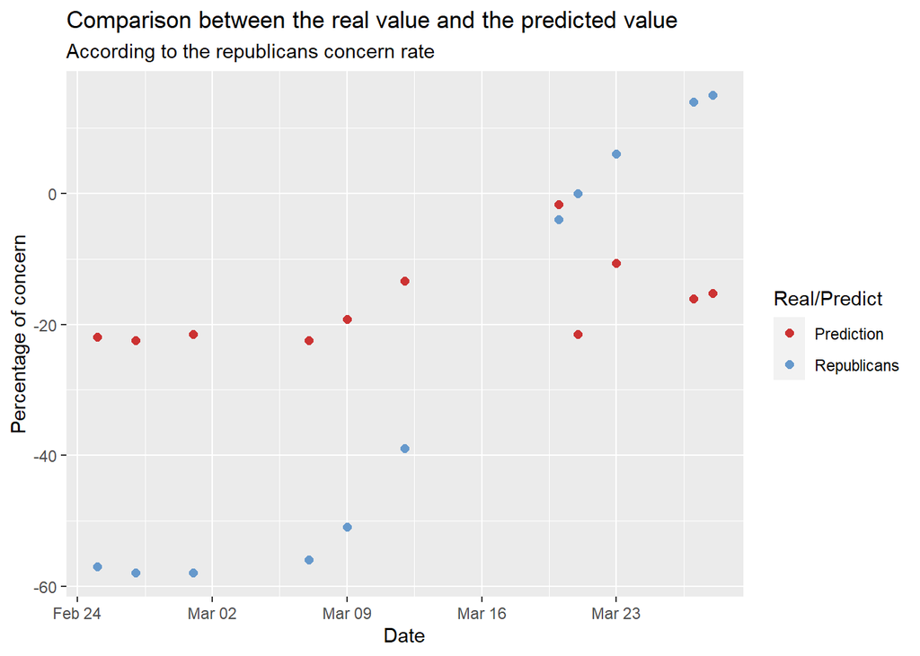

```r
colors <- c("Republicans" = "#6699cc", "Prediction" = "#cc3333")
ggplot(data = Republicans_pred, mapping = aes(x=Date)) +
  geom_point(aes(y=Republicans,color="Republicans"),size=2)+
  geom_point(aes(y=Pred,color="Prediction"),size=2)+
   labs(title = "Comparison between the real value and the predicted value",subtitle = "According to the republicans concern rate", x= "Date", y = "Percentage of concern",color = "Real/Predict")+
  scale_color_manual(values = colors)
```

### Conclusions

As we can observe in the graphs and by the high RMSE score and the low R square score the model is not significant. The model does not optimally predict the level of concern of the American public according to the parameters we have defined the sum of retweets and the negativity level of the tweets per day.